# Freddy Peralta Pitching Analysis

Author

Dave Arthur

```r
# Load package(s)
library(ggplot2)
library(dplyr)
library(tidyr)
library(patchwork)

# Load data
freddy_data <- read.csv("savant_data.csv", na.strings = c("", " ", "  ", "   ", "NA"))
```

```r
# Draw the strike zone (Use an average range of heights although the specific size of strike zone obviously varies by hitter)
x <- c(-.95,.95,.95,-.95,-.95)
z <- c(1.6,1.6,3.5,3.5,1.6)

# Store strike zone in dataframe to be able to view later
sz <- data.frame(x,z)

# Get rid of rows where we don't have a pitch type
freddy_data <- freddy_data %>%
  drop_na(pitch_type)

# Change pitch names
pitch_desc <- freddy_data$pitch_type
pitch_desc[which(pitch_desc=='CH')] <- "Changeup"
pitch_desc[which(pitch_desc=='CU')] <- "Curveball"
pitch_desc[which(pitch_desc=='FF')] <- "Four seam"
pitch_desc[which(pitch_desc=='SL')] <- "Slider"
```

```r
# Separate datasets so we can get three separate graphs based on strikeouts, singles, and HRs
freddy_strikeouts <- freddy_data[freddy_data$events == "strikeout", ]
freddy_strikeouts <- freddy_strikeouts %>%
  drop_na(events)
freddy_strikeouts <- freddy_strikeouts %>%
  drop_na(release_speed)

freddy_singles <- freddy_data[freddy_data$events == "single", ]
freddy_singles <- freddy_singles %>%
  drop_na(events)
freddy_singles <- freddy_singles %>%
  drop_na(release_speed)

freddy_hrs <- freddy_data[freddy_data$events == "home_run", ]
freddy_hrs <- freddy_hrs %>%
  drop_na(events)
freddy_hrs <- freddy_hrs %>%
  drop_na(release_speed)


# Rename pitch types for each dataset so they appear nicely on graphs
pitch_desc_k <- freddy_strikeouts$pitch_type
pitch_desc_k[which(pitch_desc_k=='CH')] <- "Changeup"
pitch_desc_k[which(pitch_desc_k=='CU')] <- "Curveball"
pitch_desc_k[which(pitch_desc_k=='FF')] <- "Four seam"
pitch_desc_k[which(pitch_desc_k=='SL')] <- "Slider"

pitch_desc_s <- freddy_singles$pitch_type
pitch_desc_s[which(pitch_desc_s=='CH')] <- "Changeup"
pitch_desc_s[which(pitch_desc_s=='CU')] <- "Curveball"
pitch_desc_s[which(pitch_desc_s=='FF')] <- "Four seam"
pitch_desc_s[which(pitch_desc_s=='SL')] <- "Slider"

pitch_desc_hr <- freddy_hrs$pitch_type
pitch_desc_hr[which(pitch_desc_hr=='CH')] <- "Changeup"
pitch_desc_hr[which(pitch_desc_hr=='CU')] <- "Curveball"
pitch_desc_hr[which(pitch_desc_hr=='FF')] <- "Four seam"
pitch_desc_hr[which(pitch_desc_hr=='SL')] <- "Slider"


# Categorize pitch speeds so that we can differentiate point size based on pitch speed on final graph
freddy_strikeouts <- freddy_strikeouts %>%
  mutate(
    speed_category = cut(
      release_speed,
      breaks = c(70, 75, 80, 85, 90, 95, 100, Inf), # Define the range breaks
      # Define the labels for the legend
      labels = c("70-75 MPH", "75-80 MPH", "80-85 MPH", "85-90 MPH", "90-95 MPH", "95-100 MPH", "100+ MPH"),
      right = FALSE, # Makes the interval [min, max), e.g., 85-90 includes 85 but not 90
      include.lowest = TRUE
    )
  )

freddy_singles <- freddy_singles %>%
  mutate(
    speed_category = cut(
      release_speed,
      breaks = c(70, 75, 80, 85, 90, 95, 100, Inf), # Define the range breaks
      # Define the labels for the legend
      labels = c("70-75 MPH", "75-80 MPH", "80-85 MPH", "85-90 MPH", "90-95 MPH", "95-100 MPH", "100+ MPH"),
      right = FALSE, # Makes the interval [min, max), e.g., 85-90 includes 85 but not 90
      include.lowest = TRUE
    )
  )

freddy_hrs <- freddy_hrs %>%
  mutate(
    speed_category = cut(
      release_speed,
      breaks = c(70, 75, 80, 85, 90, 95, 100, Inf), # Define the range breaks
      # Define the labels for the legend
      labels = c("70-75 MPH", "75-80 MPH", "80-85 MPH", "85-90 MPH", "90-95 MPH", "95-100 MPH", "100+ MPH"),
      right = FALSE, # Makes the interval [min, max), e.g., 85-90 includes 85 but not 90
      include.lowest = TRUE
    )
  )
```

```r
plot_k <- ggplot() +
# First plot the strike zone that we created
  geom_path(data = sz, aes(x=x, y=z)) +
  coord_equal() +
  theme_minimal() +
# Now plot the actual pitches
  geom_point(data = freddy_strikeouts, aes(x = plate_x, y = plate_z, size = speed_category, color = pitch_desc_k)) +
  # Label the chart
  labs(size = "Speed",
       color = "Pitch Type",
       title = "Freddy Peralta Pitch Chart",
       subtitle = "Pitches that Resulted in Strikeouts in 2025 Regular Season") +
  ylab("Feet Above Homeplate") +
  xlab("Feet Left/Right From Homeplate") +
  # Adjust size of bubbles based on pitch speed category
  scale_size_manual(
    values = c("70-75 MPH" = 0.5,
               "75-80 MPH" = 0.8,
               "80-85 MPH" = 1.2,
               "85-90 MPH" = 1.6,
               "90-95 MPH" = 2.0,
               "95-100 MPH" = 2.4,
               "100+ MPH" = 3.0),
    # Keep the breaks in the correct order for the legend
    breaks = c("70-75 MPH", "75-80 MPH", "80-85 MPH", "85-90 MPH", "90-95 MPH", "95-100 MPH", "100+ MPH")
  ) +
  # Adjust graph theme
  theme(plot.title=element_text(face="bold",hjust=-.015,vjust=0,colour="#3C3C3C",size=20),
        plot.subtitle=element_text(face="plain", hjust= -.015, vjust= .09, colour="#3C3C3C", size = 12)) +
  theme(axis.text.x=element_text(vjust = .5, size=11,colour="#535353",face="bold")) +
  theme(axis.text.y=element_text(size=11,colour="#535353",face="bold")) +
  theme(axis.title.y=element_text(size=11,colour="#535353",face="bold",vjust=1.5)) +
  theme(axis.title.x=element_text(size=11,colour="#535353",face="bold",vjust=0)) +
  theme(panel.grid.major.y = element_line(color = "#bad2d4", size = .5)) +
  theme(panel.grid.major.x = element_line(color = "#bdd2d4", size = .5)) +
  theme(panel.background = element_rect(fill = "white"))
```

```r
plot_singles <- ggplot() +
# First plot the strike zone that we created
  geom_path(data = sz, aes(x=x, y=z)) +
  coord_equal() +
  theme_minimal() +
# Now plot the actual pitches
  geom_point(data = freddy_singles, aes(x = plate_x, y = plate_z, size = speed_category, color = pitch_desc_s)) +
  labs(size = "Speed",
       color = "Pitch Type",
       title = "Freddy Peralta Pitch Chart",
       subtitle = "Pitches that Resulted in Singles in 2025 Regular Season") +
  ylab("Feet Above Homeplate") +
  xlab("Feet Left/Right From Homeplate") +
  scale_size_manual(
    values = c("70-75 MPH" = 0.5,
               "75-80 MPH" = 0.8,
               "80-85 MPH" = 1.2,
               "85-90 MPH" = 1.6,
               "90-95 MPH" = 2.0,
               "95-100 MPH" = 2.4,
               "100+ MPH" = 3.0),
    breaks = c("70-75 MPH", "75-80 MPH", "80-85 MPH", "85-90 MPH", "90-95 MPH", "95-100 MPH", "100+ MPH")
  ) +
  theme(plot.title=element_text(face="bold",hjust=-.015,vjust=0,colour="#3C3C3C",size=20),
        plot.subtitle=element_text(face="plain", hjust= -.015, vjust= .09, colour="#3C3C3C", size = 12)) +
  theme(axis.text.x=element_text(vjust = .5, size=11,colour="#535353",face="bold")) +
  theme(axis.text.y=element_text(size=11,colour="#535353",face="bold")) +
  theme(axis.title.y=element_text(size=11,colour="#535353",face="bold",vjust=1.5)) +
  theme(axis.title.x=element_text(size=11,colour="#535353",face="bold",vjust=0)) +
  theme(panel.grid.major.y = element_line(color = "#bad2d4", size = .5)) +
  theme(panel.grid.major.x = element_line(color = "#bdd2d4", size = .5)) +
  theme(panel.background = element_rect(fill = "white"))
```

```r
plot_hrs <- ggplot() +
# First plot the strike zone that we created
  geom_path(data = sz, aes(x=x, y=z)) +
  coord_equal() +
  theme_minimal() +
# Now plot the actual pitches
  geom_point(data = freddy_hrs, aes(x = plate_x, y = plate_z, size = speed_category, color = pitch_desc_hr)) +
  labs(size = "Speed",
       color = "Pitch Type",
       title = "Freddy Peralta Pitch Chart",
       subtitle = "Pitches that Resulted in Home Runs in 2025 Regular Season") +
  ylab("Feet Above Homeplate") +
  xlab("Feet Left/Right From Homeplate") +
  scale_size_manual(
    values = c("70-75 MPH" = 0.5,
               "75-80 MPH" = 0.8,
               "80-85 MPH" = 1.2,
               "85-90 MPH" = 1.6,
               "90-95 MPH" = 2.0,
               "95-100 MPH" = 2.4,
               "100+ MPH" = 3.0),
    breaks = c("70-75 MPH", "75-80 MPH", "80-85 MPH", "85-90 MPH", "90-95 MPH", "95-100 MPH", "100+ MPH")
  ) +
  theme(plot.title=element_text(face="bold",hjust=-.015,vjust=0,colour="#3C3C3C",size=20),
        plot.subtitle=element_text(face="plain", hjust= -.015, vjust= .09, colour="#3C3C3C", size = 12)) +
  theme(axis.text.x=element_text(vjust = .5, size=11,colour="#535353",face="bold")) +
  theme(axis.text.y=element_text(size=11,colour="#535353",face="bold")) +
  theme(axis.title.y=element_text(size=11,colour="#535353",face="bold",vjust=1.5)) +
  theme(axis.title.x=element_text(size=11,colour="#535353",face="bold",vjust=0)) +
  theme(panel.grid.major.y = element_line(color = "#bad2d4", size = .5)) +
  theme(panel.grid.major.x = element_line(color = "#bdd2d4", size = .5)) +
  theme(panel.background = element_rect(fill = "white"))
```

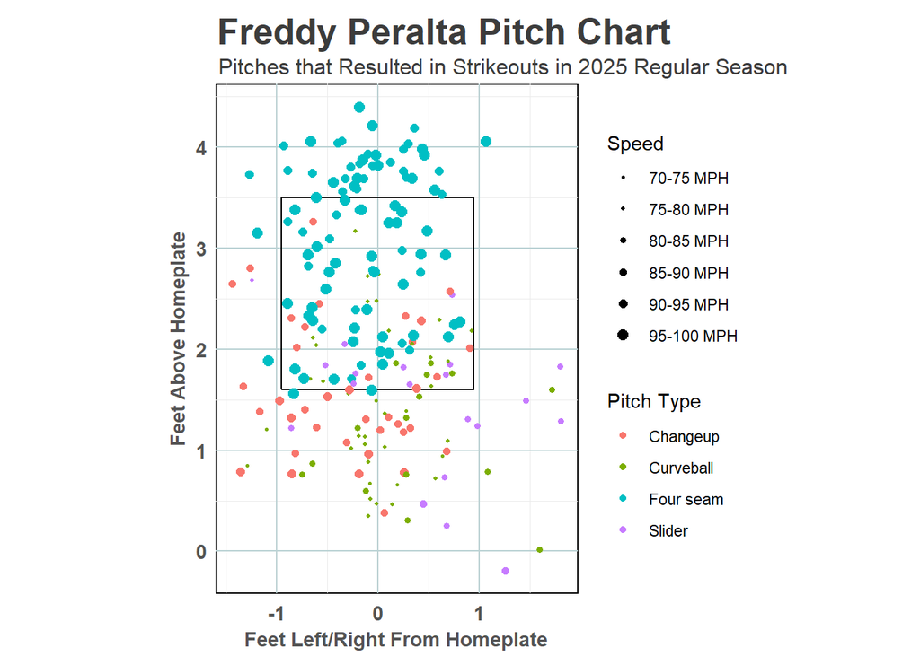

```r
plot_k
```

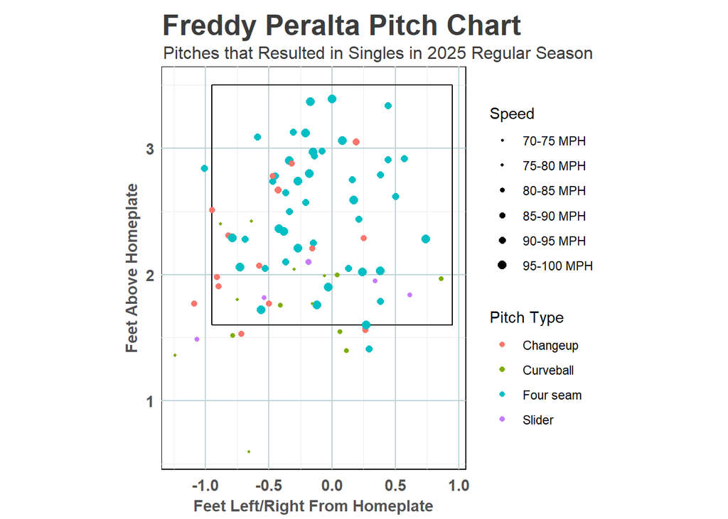

```r
plot_singles
```

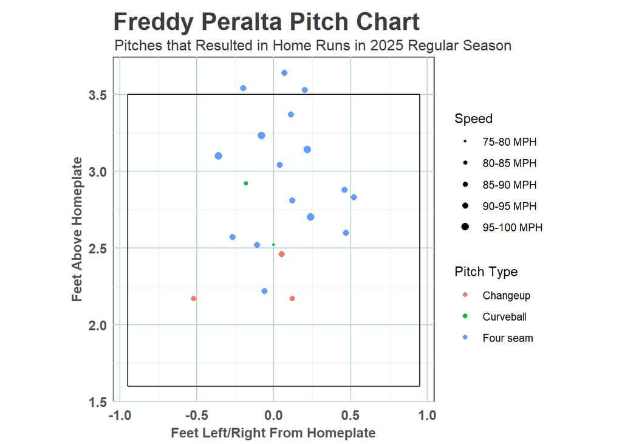

```r
plot_hrs
```

As seen in the three charts, the pitches Freddy Peralta made during the 2025 regular season that resulted in strikeouts and singles tended to be widely distributed in terms of location within the strike zone. However, home runs that were hit off Peralta were concentrated horizontally in the center of the strike zone, with none that much more than half a foot off a vertical line from the center of homeplate. The home run pitches also vertically ended up in the middle or high end of the strike zone. Another key takeaway is that pitches that resulted in home runs were overwhelmingly four-seam fastballs, with four-seam pitches making up 16 of the 21 home run pitches. While Peralta threw a significant proportion of changeups, curveballs, and sliders in the pitches that resulted in strikeouts and singles, only 3 changeups, 2 curveballs, and no sliders resulted in home runs. Sliders were particularly successful as only five of that category ended up as singles, and even though many sliders missed the strike zone, they were more often than not called as strikes (or swung at and missed by the batter), resulting in a strikeout. Many curveballs had the same pattern of missing the strike zone low and to the right yet resulting in a called strike or a missed swing. For future analysis, it would be helpful to break down these strikes outside the strike zone to determine if they were strikes looking or strikes swinging. If many of the pitches are strikes looking, then Peralta’s curveballs and sliders may be more prone to challenges by opposing teams with the advent of the ABS system in the major leagues.